# Networks: structure, evolution & processes

**Internet Analytics - Lab 2**

**Group:** *Q*

**Names:**

- *Luka Secilmis*
- *Thomas Ecabert*
- *Aymeric Bacuet*
- *Berkay Güler*

## 2.3 Epidemics

#### Exercise 2.9: Simulate an epidemic outbreak

```python
import epidemics_helper
import networkx as nx
import json
from networkx.readwrite import json_graph
import matplotlib.pyplot as plt
import numpy as np
import random
```

```python
# Load data and create our random network G
data = json.load(open('../data/nyc_augmented_network.json'))
directed = data.pop('directed')
multigraph = data.pop('multigraph')

G = json_graph.node_link_graph(data, directed = directed, multigraph = multigraph)
```

#### Simulation of COVID-19 epidemic in New York for 100 days.

```python
# Parameters
infection_rate = 10.0
recovery_rate = 0.1
patient_0 = 23654
time = 100

# Create and launch SIR epidemic
SIR = epidemics_helper.SimulationSIR(G, beta = infection_rate, gamma = recovery_rate)
SIR.launch_epidemic(source = patient_0, max_time = time)
```

```
Epidemic stopped after 101.05 days | 101.05 days elapsed | 0.1% susceptible, 0.0% infected, 99.9% recovered
```

#### Evolution of the epidemic over time

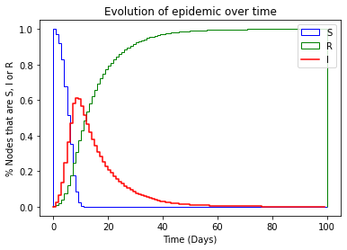

```python
# Time of infection/recovery for each node in G
infection_times = []
recovery_times = []
for v in G.nodes():
    infection_times.append(SIR.inf_time[v])
    recovery_times.append(SIR.rec_time[v])

# Evolution of epidemic over time - histogram
# We split up our time into 100 equal width bins

# Susceptible nodes - plot infection times with reversed direction of accumulation
#                    ie. each bin gives the count for all bins of larger values
S, _, _ = plt.hist(infection_times, bins = 100, range=[0.0, 100.0], cumulative=-1,
                               histtype='step', label='S', density=True, color='blue')

# Recovered nodes - plot recovery times cumulatively
#                  ie. each bin gives the count for that bin plus all bins of smaller values
R, _, _ = plt.hist(recovery_times, bins = 100, range=[0.0, 100.0], cumulative=True,
                               histtype='step', label='R', density=True, color='green')

# Infected nodes - plot 1 - (S + R)
#         (we cannot plot infection_times cumulatively as then we don't take into account when a node recovers)
plt.step(range(100), 1 - (S + R), where='post', label='I', color='red')

plt.title('Evolution of epidemic over time')
plt.xlabel('Time (Days)')
plt.ylabel('% Nodes that are S, I or R')
plt.legend()
plt.show()
```

```python
print(f'It took {np.argwhere(1 - (S + R) >= 0.6)[0][0]} days until 60% of the population was infected')
print(f'It took {np.argwhere(R >= 0.6)[0][0]} days until 60% of the population recovered')
```

```
It took 8 days until 60% of the population was infected
It took 14 days until 60% of the population recovered
```

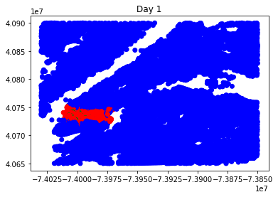

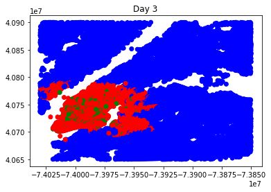

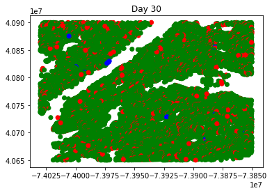

```python
# Node coordinates
x_coords = []
y_coords = []
for v in G.nodes():
    x_coords.append(G.nodes[v]['coordinates'][0])
    y_coords.append(G.nodes[v]['coordinates'][1])

# SIR Colors for days 1, 3, 30
colors_day1 = []
colors_day3 = []
colors_day30 = []

# Assign colors by first checking for recovery as recovery must happen after infection
# We are looking at the end of Day x - we check for less than or equal x
for v in G.nodes():
    r = SIR.rec_time[v]
    i = SIR.inf_time[v]
    if r <= 30:
        colors_day30.append('green')
    elif i <= 30:
        colors_day30.append('red')
    else:
        colors_day30.append('blue')

    if r <= 3:
        colors_day3.append('green')
    elif i <= 3:
        colors_day3.append('red')
    else:
        colors_day3.append('blue')

    if r <= 1:
        colors_day1.append('green')
    elif i <= 1:
        colors_day1.append('red')
    else:
        colors_day1.append('blue')

# Visualize the SIR Model on Day 1, 3, 30
plt.title('Day 1')
plt.scatter(x_coords, y_coords, c=colors_day1)
plt.show()

plt.title('Day 3')
plt.scatter(x_coords, y_coords, c=colors_day3)
plt.show()

plt.title('Day 30')
plt.scatter(x_coords, y_coords, c=colors_day30)
plt.show()
```

### 2.3.1 Stop the apocalypse!

#### Exercise 2.10: Strategy 1

```python
# Strategy 1
def Strategy1(budget, nb_simulations):
    G_1 = G.copy()
    for _ in range(budget):
        random_edge = random.choice(list(G_1.edges()))
        G_1.remove_edge(random_edge[0], random_edge[1])

    S_av = 0
    I_av = 0
    R_av = 0
    for _ in range(nb_simulations):
        SIR = epidemics_helper.SimulationSIR(G_1, beta=10.0, gamma=0.1)
        patient_0 = random.choice(list(G_1.nodes()))

        SIR.launch_epidemic(source = patient_0, max_time = 30)

        n = len(list(G_1.nodes()))
        S_av += np.sum(SIR.status == 0) / n
        I_av += np.sum(SIR.status == 1) / n
        R_av += np.sum(SIR.status == 2) / n

    print(f'After {nb_simulations} simulations, on average {100 * S_av / nb_simulations} % are healthy on Day 30')
    print(f'After {nb_simulations} simulations, on average {100 * I_av / nb_simulations} % are infected on Day 30')
    print(f'After {nb_simulations} simulations, on average {100 * R_av / nb_simulations} % are recovered on Day 30')
```

```python
# Strategy 1: Remove edges at random - budget = 1000 edges
# We initially simulated with 100 simulations but this printed too many results
#                   - and we saw that 10 simulations gave approximately the same averages
Strategy1(1000, 50)
```

```
Epidemic stopped after 30.00 days | 30.00 days elapsed | 0.6% susceptible, 11.0% infected, 88.4% recovered
Epidemic stopped after 30.00 days | 30.00 days elapsed | 0.6% susceptible, 8.8% infected, 90.6% recovered
Epidemic stopped after 30.00 days | 30.00 days elapsed | 0.9% susceptible, 8.8% infected, 90.3% recovered
Epidemic stopped after 30.00 days | 30.00 days elapsed | 0.5% susceptible, 11.6% infected, 88.0% recovered
Epidemic stopped after 30.00 days | 30.00 days elapsed | 0.5% susceptible, 10.1% infected, 89.4% recovered
Epidemic stopped after 30.00 days | 30.00 days elapsed | 0.5% susceptible, 9.1% infected, 90.4% recovered
Epidemic stopped after 30.00 days | 30.00 days elapsed | 0.5% susceptible, 8.0% infected, 91.5% recovered
Epidemic stopped after 30.00 days | 30.00 days elapsed | 0.5% susceptible, 9.6% infected, 89.9% recovered
Epidemic stopped after 30.00 days | 30.00 days elapsed | 0.6% susceptible, 9.6% infected, 89.9% recovered
Epidemic stopped after 30.00 days | 30.00 days elapsed | 0.5% susceptible, 9.8% infected, 89.6% recovered
Epidemic stopped after 30.00 days | 30.00 days elapsed | 0.5% susceptible, 9.8% infected, 89.7% recovered
Epidemic stopped after 30.00 days | 30.00 days elapsed | 0.6% susceptible, 11.4% infected, 88.1% recovered
Epidemic stopped after 30.00 days | 30.00 days elapsed | 0.6% susceptible, 8.9% infected, 90.6% recovered
Epidemic stopped after 30.00 days | 30.00 days elapsed | 0.5% susceptible, 9.1% infected, 90.4% recovered
Epidemic stopped after 30.00 days | 30.00 days elapsed | 0.5% susceptible, 10.4% infected, 89.1% recovered
Epidemic stopped after 30.00 days | 30.00 days elapsed | 0.6% susceptible, 10.0% infected, 89.5% recovered
Epidemic stopped after 30.00 days | 30.00 days elapsed | 0.5% susceptible, 9.5% infected, 89.9% recovered
Epidemic stopped after 30.01 days | 30.01 days elapsed | 0.5% susceptible, 8.9% infected, 90.6% recovered
Epidemic stopped after 30.00 days | 30.00 days elapsed | 0.5% susceptible, 10.6% infected, 88.9% recovered
Epidemic stopped after 30.00 days | 30.00 days elapsed | 0.5% susceptible, 10.2% infected, 89.2% recovered
Epidemic stopped after 30.00 days | 30.00 days elapsed | 0.6% susceptible, 14.0% infected, 85.4% recovered
Epidemic stopped after 30.00 days | 30.00 days elapsed | 0.6% susceptible, 8.8% infected, 90.6% recovered
Epidemic stopped after 30.00 days | 30.00 days elapsed | 0.7% susceptible, 8.9% infected, 90.4% recovered
Epidemic stopped after 30.01 days | 30.01 days elapsed | 0.5% susceptible, 9.8% infected, 89.7% recovered
Epidemic stopped after 30.00 days | 30.00 days elapsed | 0.6% susceptible, 10.2% infected, 89.2% recovered
Epidemic stopped after 30.00 days | 30.00 days elapsed | 0.6% susceptible, 8.9% infected, 90.5% recovered
Epidemic stopped after 30.00 days | 30.00 days elapsed | 0.5% susceptible, 8.8% infected, 90.6% recovered
Epidemic stopped after 30.01 days | 30.01 days elapsed | 0.6% susceptible, 9.5% infected, 89.9% recovered
Epidemic stopped after 30.00 days | 30.00 days elapsed | 0.6% susceptible, 9.2% infected, 90.2% recovered
Epidemic stopped after 30.00 days | 30.00 days elapsed | 0.6% susceptible, 9.2% infected, 90.2% recovered
Epidemic stopped after 30.00 days | 30.00 days elapsed | 0.6% susceptible, 8.7% infected, 90.7% recovered
Epidemic stopped after 30.00 days | 30.00 days elapsed | 0.6% susceptible, 10.3% infected, 89.1% recovered
Epidemic stopped after 30.00 days | 30.00 days elapsed | 0.5% susceptible, 9.6% infected, 89.9% recovered
Epidemic stopped after 30.00 days | 30.00 days elapsed | 0.6% susceptible, 11.2% infected, 88.3% recovered
Epidemic stopped after 30.00 days | 30.00 days elapsed | 0.6% susceptible, 11.6% infected, 87.8% recovered
Epidemic stopped after 30.00 days | 30.00 days elapsed | 0.5% susceptible, 11.8% infected, 87.6% recovered
Epidemic stopped after 30.00 days | 30.00 days elapsed | 0.5% susceptible, 9.7% infected, 89.8% recovered
Epidemic stopped after 30.00 days | 30.00 days elapsed | 0.5% susceptible, 8.4% infected, 91.1% recovered
Epidemic stopped after 30.00 days | 30.00 days elapsed | 0.6% susceptible, 9.0% infected, 90.4% recovered
Epidemic stopped after 30.00 days | 30.00 days elapsed | 0.6% susceptible, 9.5% infected, 89.9% recovered
Epidemic stopped after 30.00 days | 30.00 days elapsed | 0.5% susceptible, 10.6% infected, 88.9% recovered
Epidemic stopped after 30.00 days | 30.00 days elapsed | 0.5% susceptible, 10.1% infected, 89.4% recovered
Epidemic stopped after 30.00 days | 30.00 days elapsed | 0.5% susceptible, 10.0% infected, 89.5% recovered
Epidemic stopped after 30.00 days | 30.00 days elapsed | 0.5% susceptible, 8.5% infected, 91.0% recovered
Epidemic stopped after 30.00 days | 30.00 days elapsed | 0.5% susceptible, 8.4% infected, 91.1% recovered
Epidemic stopped after 30.00 days | 30.00 days elapsed | 0.5% susceptible, 14.0% infected, 85.5% recovered
Epidemic stopped after 30.00 days | 30.00 days elapsed | 0.5% susceptible, 8.1% infected, 91.4% recovered
Epidemic stopped after 30.00 days | 30.00 days elapsed | 0.6% susceptible, 13.2% infected, 86.3% recovered
Epidemic stopped after 30.00 days | 30.00 days elapsed | 0.5% susceptible, 9.5% infected, 90.0% recovered
Epidemic stopped after 30.00 days | 30.00 days elapsed | 0.6% susceptible, 9.7% infected, 89.8% recovered
After 50 simulations, on average 0.5509610664249841 % are healthy on Day 30
After 50 simulations, on average 9.889807786715004 % are infected on Day 30
After 50 simulations, on average 89.55923114686001 % are recovered on Day 30
```

#### Is this strategy effective?

No this strategy with this budget is not effective, as on average around 99% of the population contracted COVID-19 during 30 days.

```python
# Now we increase the budget to 10000 edges
Strategy1(10000, 50)
```

```
Epidemic stopped after 30.00 days | 30.00 days elapsed | 9.8% susceptible, 18.7% infected, 71.5% recovered
Epidemic stopped after 24.59 days | 24.59 days elapsed | 100.0% susceptible, 0.0% infected, 0.0% recovered
Epidemic stopped after 30.00 days | 30.00 days elapsed | 9.9% susceptible, 15.2% infected, 74.8% recovered
Epidemic stopped after 30.02 days | 30.02 days elapsed | 85.7% susceptible, 1.8% infected, 12.5% recovered
Epidemic stopped after 30.00 days | 30.00 days elapsed | 10.3% susceptible, 18.2% infected, 71.5% recovered
Epidemic stopped after 30.01 days | 30.01 days elapsed | 9.8% susceptible, 11.0% infected, 79.2% recovered
Epidemic stopped after 30.03 days | 30.03 days elapsed | 85.1% susceptible, 1.3% infected, 13.6% recovered
Epidemic stopped after 30.00 days | 30.00 days elapsed | 10.2% susceptible, 13.2% infected, 76.7% recovered
Epidemic stopped after 30.00 days | 30.00 days elapsed | 9.8% susceptible, 13.3% infected, 76.8% recovered
Epidemic stopped after 43.79 days | 43.79 days elapsed | 100.0% susceptible, 0.0% infected, 0.0% recovered
Epidemic stopped after 30.00 days | 30.00 days elapsed | 9.8% susceptible, 15.2% infected, 75.1% recovered
Epidemic stopped after 30.00 days | 30.00 days elapsed | 10.1% susceptible, 10.9% infected, 79.0% recovered
Epidemic stopped after 30.00 days | 30.00 days elapsed | 9.9% susceptible, 15.1% infected, 75.0% recovered
Epidemic stopped after 30.00 days | 30.00 days elapsed | 24.8% susceptible, 18.1% infected, 57.1% recovered
Epidemic stopped after 30.00 days | 30.00 days elapsed | 9.8% susceptible, 11.8% infected, 78.4% recovered
Epidemic stopped after 30.00 days | 30.00 days elapsed | 10.6% susceptible, 13.7% infected, 75.7% recovered
Epidemic stopped after 30.20 days | 30.20 days elapsed | 99.1% susceptible, 0.0% infected, 0.9% recovered
Epidemic stopped after 30.00 days | 30.00 days elapsed | 10.3% susceptible, 16.9% infected, 72.8% recovered
Epidemic stopped after 30.00 days | 30.00 days elapsed | 10.1% susceptible, 10.3% infected, 79.6% recovered
Epidemic stopped after 30.00 days | 30.00 days elapsed | 9.7% susceptible, 10.2% infected, 80.2% recovered
Epidemic stopped after 30.00 days | 30.00 days elapsed | 10.4% susceptible, 9.8% infected, 79.8% recovered
Epidemic stopped after 8.50 days | 8.50 days elapsed | 100.0% susceptible, 0.0% infected, 0.0% recovered
Epidemic stopped after 30.00 days | 30.00 days elapsed | 11.3% susceptible, 9.8% infected, 78.9% recovered
Epidemic stopped after 30.00 days | 30.00 days elapsed | 9.8% susceptible, 14.1% infected, 76.1% recovered
Epidemic stopped after 30.00 days | 30.00 days elapsed | 10.0% susceptible, 9.9% infected, 80.2% recovered
Epidemic stopped after 30.00 days | 30.00 days elapsed | 10.4% susceptible, 13.7% infected, 76.0% recovered
Epidemic stopped after 6.47 days | 6.47 days elapsed | 100.0% susceptible, 0.0% infected, 0.0% recovered
Epidemic stopped after 30.00 days | 30.00 days elapsed | 9.9% susceptible, 11.6% infected, 78.6% recovered
Epidemic stopped after 30.01 days | 30.01 days elapsed | 10.7% susceptible, 14.4% infected, 74.9% recovered
Epidemic stopped after 30.00 days | 30.00 days elapsed | 9.8% susceptible, 21.7% infected, 68.5% recovered
Epidemic stopped after 30.00 days | 30.00 days elapsed | 24.7% susceptible, 11.4% infected, 63.9% recovered
Epidemic stopped after 30.01 days | 30.01 days elapsed | 9.9% susceptible, 12.5% infected, 77.6% recovered
Epidemic stopped after 30.00 days | 30.00 days elapsed | 10.5% susceptible, 16.0% infected, 73.5% recovered
Epidemic stopped after 30.01 days | 30.01 days elapsed | 9.8% susceptible, 11.8% infected, 78.4% recovered
Epidemic stopped after 30.00 days | 30.00 days elapsed | 10.0% susceptible, 13.1% infected, 76.9% recovered
Epidemic stopped after 30.00 days | 30.00 days elapsed | 9.9% susceptible, 15.9% infected, 74.2% recovered
Epidemic stopped after 30.00 days | 30.00 days elapsed | 10.3% susceptible, 12.1% infected, 77.7% recovered
Epidemic stopped after 30.00 days | 30.00 days elapsed | 9.8% susceptible, 9.9% infected, 80.2% recovered
Epidemic stopped after 30.00 days | 30.00 days elapsed | 10.0% susceptible, 11.2% infected, 78.8% recovered
Epidemic stopped after 30.00 days | 30.00 days elapsed | 10.2% susceptible, 16.1% infected, 73.8% recovered
Epidemic stopped after 30.00 days | 30.00 days elapsed | 12.9% susceptible, 13.5% infected, 73.6% recovered
Epidemic stopped after 30.00 days | 30.00 days elapsed | 10.0% susceptible, 20.3% infected, 69.7% recovered
Epidemic stopped after 30.00 days | 30.00 days elapsed | 12.7% susceptible, 11.8% infected, 75.4% recovered
Epidemic stopped after 30.00 days | 30.00 days elapsed | 14.0% susceptible, 10.1% infected, 75.9% recovered
Epidemic stopped after 30.00 days | 30.00 days elapsed | 9.7% susceptible, 12.6% infected, 77.7% recovered
Epidemic stopped after 30.00 days | 30.00 days elapsed | 10.3% susceptible, 12.6% infected, 77.1% recovered
Epidemic stopped after 30.01 days | 30.01 days elapsed | 12.5% susceptible, 10.3% infected, 77.2% recovered
Epidemic stopped after 30.00 days | 30.00 days elapsed | 9.7% susceptible, 11.7% infected, 78.6% recovered
Epidemic stopped after 30.00 days | 30.00 days elapsed | 10.0% susceptible, 12.6% infected, 77.4% recovered
Epidemic stopped after 30.00 days | 30.00 days elapsed | 9.9% susceptible, 14.0% infected, 76.1% recovered
After 50 simulations, on average 22.870284354820413 % are healthy on Day 30
After 50 simulations, on average 11.590423322382083 % are infected on Day 30
After 50 simulations, on average 65.53929232279751 % are recovered on Day 30
```

#### Is this strategy effective?

When we increase the budget to 10000 edges, the strategy becomes much more effective as now, on average, around 23% of the population has not been infected during the 30 days.

#### Exercise 2.11: Strategy 2

The strategy we decided on is not to remove edges at random, but rather attack local bridges. In the course we learned that social ties to other communities usually go through weak links. Thus by attacking and removing local bridges we break these ties between communities and increase the shortest paths between communities to try to contain infections within the community they start in.

Furthermore in the documentation of NetworkX we saw that the function local_bridges() can also return the span of the local bridges - which "is the shortest path length between the endpoints if the local bridge is removed." Thus by sorting this set of bridges in descending order, we can remove the local bridges with the largest spans, and contain infections even more effectively.

```python
# Strategy 2
def Strategy2(budget, nb_simulations):
    G_2 = G.copy()

    # span of a local bridge is the shortest path length between the endpoints if the local bridge is removed.
    local_bridges = list(nx.local_bridges(G_2, with_span=True))

    # sort these local bridges according to their span in descending order
    local_bridges = sorted(local_bridges, key=lambda x: - x[2])

    for i in range(budget):
        high_span_edge = local_bridges[i]
        G_2.remove_edge(high_span_edge[0], high_span_edge[1])

    S_av = 0
    I_av = 0
    R_av = 0
    for _ in range(nb_simulations):
        SIR = epidemics_helper.SimulationSIR(G_2, beta=10.0, gamma=0.1)
        patient_0 = random.choice(list(G_2.nodes()))

        SIR.launch_epidemic(source = patient_0, max_time = 30)

        n = len(list(G_2.nodes()))
        S_av += np.sum(SIR.status == 0) / n
        I_av += np.sum(SIR.status == 1) / n
        R_av += np.sum(SIR.status == 2) / n

    print(f'After {nb_simulations} simulations, on average {100 * S_av / nb_simulations} % are healthy on Day 30')
    print(f'After {nb_simulations} simulations, on average {100 * I_av / nb_simulations} % are infected on Day 30')
    print(f'After {nb_simulations} simulations, on average {100 * R_av / nb_simulations} % are recovered on Day 30')
```

```python
# Strategy 2 - budget = 2500 egdes
Strategy2(2500, 50)
```

```
Epidemic stopped after 5.94 days | 5.94 days elapsed | 100.0% susceptible, 0.0% infected, 0.0% recovered
Epidemic stopped after 30.01 days | 30.01 days elapsed | 58.0% susceptible, 3.0% infected, 39.0% recovered
Epidemic stopped after 30.00 days | 30.00 days elapsed | 58.0% susceptible, 3.4% infected, 38.6% recovered
Epidemic stopped after 30.00 days | 30.00 days elapsed | 86.2% susceptible, 0.9% infected, 12.9% recovered
Epidemic stopped after 30.02 days | 30.02 days elapsed | 83.6% susceptible, 1.4% infected, 15.0% recovered
Epidemic stopped after 8.80 days | 8.80 days elapsed | 100.0% susceptible, 0.0% infected, 0.0% recovered
Epidemic stopped after 30.06 days | 30.06 days elapsed | 86.2% susceptible, 1.3% infected, 12.5% recovered
Epidemic stopped after 30.03 days | 30.03 days elapsed | 83.8% susceptible, 1.0% infected, 15.1% recovered
Epidemic stopped after 30.01 days | 30.01 days elapsed | 58.0% susceptible, 3.0% infected, 39.0% recovered
Epidemic stopped after 30.01 days | 30.01 days elapsed | 83.6% susceptible, 1.0% infected, 15.4% recovered
Epidemic stopped after 30.03 days | 30.03 days elapsed | 83.6% susceptible, 1.0% infected, 15.5% recovered
Epidemic stopped after 16.16 days | 16.16 days elapsed | 100.0% susceptible, 0.0% infected, 0.0% recovered
Epidemic stopped after 30.01 days | 30.01 days elapsed | 58.0% susceptible, 2.9% infected, 39.1% recovered
Epidemic stopped after 30.00 days | 30.00 days elapsed | 58.0% susceptible, 3.2% infected, 38.8% recovered
Epidemic stopped after 30.02 days | 30.02 days elapsed | 83.8% susceptible, 1.1% infected, 15.1% recovered
Epidemic stopped after 30.01 days | 30.01 days elapsed | 83.8% susceptible, 1.0% infected, 15.2% recovered
Epidemic stopped after 30.02 days | 30.02 days elapsed | 83.6% susceptible, 1.3% infected, 15.1% recovered
Epidemic stopped after 30.04 days | 30.04 days elapsed | 83.8% susceptible, 1.1% infected, 15.1% recovered
Epidemic stopped after 30.01 days | 30.01 days elapsed | 58.0% susceptible, 3.2% infected, 38.8% recovered
Epidemic stopped after 30.01 days | 30.01 days elapsed | 83.8% susceptible, 1.0% infected, 15.2% recovered
Epidemic stopped after 30.00 days | 30.00 days elapsed | 58.0% susceptible, 2.8% infected, 39.2% recovered
Epidemic stopped after 30.02 days | 30.02 days elapsed | 58.0% susceptible, 2.9% infected, 39.1% recovered
Epidemic stopped after 30.02 days | 30.02 days elapsed | 58.0% susceptible, 3.3% infected, 38.7% recovered
Epidemic stopped after 0.85 days | 0.85 days elapsed | 100.0% susceptible, 0.0% infected, 0.0% recovered
Epidemic stopped after 30.03 days | 30.03 days elapsed | 83.8% susceptible, 1.0% infected, 15.2% recovered
Epidemic stopped after 30.06 days | 30.06 days elapsed | 86.2% susceptible, 1.1% infected, 12.7% recovered
Epidemic stopped after 30.02 days | 30.02 days elapsed | 58.0% susceptible, 3.0% infected, 39.0% recovered
Epidemic stopped after 30.01 days | 30.01 days elapsed | 58.0% susceptible, 2.9% infected, 39.1% recovered
Epidemic stopped after 30.09 days | 30.09 days elapsed | 83.8% susceptible, 1.1% infected, 15.1% recovered
Epidemic stopped after 30.03 days | 30.03 days elapsed | 58.0% susceptible, 3.2% infected, 38.8% recovered
Epidemic stopped after 30.03 days | 30.03 days elapsed | 83.8% susceptible, 1.0% infected, 15.2% recovered
Epidemic stopped after 30.01 days | 30.01 days elapsed | 86.2% susceptible, 1.3% infected, 12.5% recovered
Epidemic stopped after 30.07 days | 30.07 days elapsed | 86.2% susceptible, 1.0% infected, 12.7% recovered
Epidemic stopped after 30.00 days | 30.00 days elapsed | 58.0% susceptible, 2.7% infected, 39.3% recovered
Epidemic stopped after 30.05 days | 30.05 days elapsed | 83.8% susceptible, 1.0% infected, 15.1% recovered
Epidemic stopped after 30.01 days | 30.01 days elapsed | 58.0% susceptible, 3.2% infected, 38.8% recovered
Epidemic stopped after 30.00 days | 30.00 days elapsed | 58.0% susceptible, 3.0% infected, 39.0% recovered
Epidemic stopped after 30.01 days | 30.01 days elapsed | 58.0% susceptible, 2.7% infected, 39.3% recovered
Epidemic stopped after 30.03 days | 30.03 days elapsed | 83.8% susceptible, 1.1% infected, 15.1% recovered
Epidemic stopped after 30.00 days | 30.00 days elapsed | 58.0% susceptible, 3.6% infected, 38.4% recovered
Epidemic stopped after 39.36 days | 39.36 days elapsed | 100.0% susceptible, 0.0% infected, 0.0% recovered
Epidemic stopped after 30.02 days | 30.02 days elapsed | 86.2% susceptible, 0.9% infected, 12.9% recovered
Epidemic stopped after 30.02 days | 30.02 days elapsed | 58.0% susceptible, 3.7% infected, 38.3% recovered
Epidemic stopped after 30.00 days | 30.00 days elapsed | 58.0% susceptible, 3.4% infected, 38.6% recovered
Epidemic stopped after 1.27 days | 1.27 days elapsed | 100.0% susceptible, 0.0% infected, 0.0% recovered
Epidemic stopped after 30.00 days | 30.00 days elapsed | 58.0% susceptible, 2.8% infected, 39.2% recovered
Epidemic stopped after 30.00 days | 30.00 days elapsed | 83.8% susceptible, 1.2% infected, 15.0% recovered
Epidemic stopped after 30.00 days | 30.00 days elapsed | 58.0% susceptible, 3.1% infected, 39.0% recovered
Epidemic stopped after 30.04 days | 30.04 days elapsed | 83.8% susceptible, 1.0% infected, 15.2% recovered
Epidemic stopped after 30.02 days | 30.02 days elapsed | 86.2% susceptible, 1.1% infected, 12.7% recovered
After 50 simulations, on average 75.22578452475364 % are healthy on Day 30
After 50 simulations, on average 1.7990257165514894 % are infected on Day 30
After 50 simulations, on average 22.97518975869492 % are recovered on Day 30
```

As we see this strategy is extremely effective, with a budget of 2500 edges we manage to keep around 75% of the population healthy by day 30